# Final Report for Intro to Data Science

Griffin Sun

# Introduction

Hello, I am Griffin Sun and this is my final project for Intro to Data science. The data set I am using has collated the top 50 songs on Spotify in 2019 and characterizes the songs by certain attributes such as

- Dance-ability
- Energy
- Loudness
- Valence
- Beats Per Minute

We all know the four chords that pervade modern music but I want to see if attributes like a songs dance-ability or energy have an effect on its popularity.

# Preparation

lock and load the packages

```r
#install.packages("tidyverse")
#install.packages("ggplot2")
#install.packages("dplyr")
#install.packages("ggcorrplot")
```

```r
library(ggcorrplot)
library(tidyverse)
library(ggplot2)
library(dplyr)
```

Load the data

```r
library(readr)
dat <- read_csv("top50.csv")
```

```
## * `` -> ...1
```

# Analysis

## Averages and Range

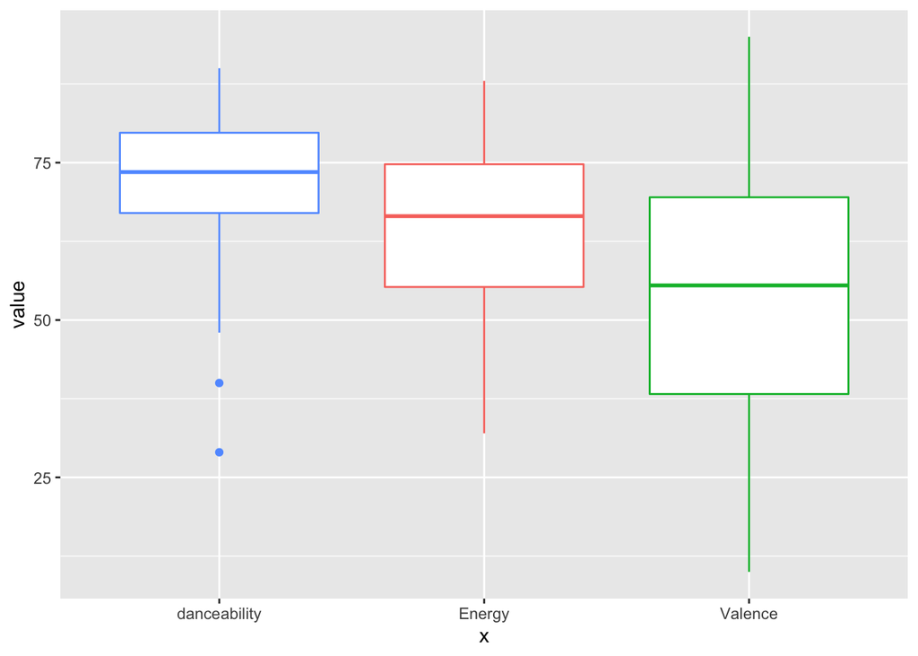

```r
#prepare the data to chart
dance<- "#ff825c"
energy<- "#88a44e"
loud<- "#1e9e9e"
BP<- "#c7993b"
val<- "#a1a141"

dat%>%
  ggplot()+
  geom_boxplot(aes(x="danceability",y=Danceability,color=dance,))+
  geom_boxplot(aes(x="Energy",y=Energy,color=energy))+
  geom_boxplot(aes(x="Valence",y=Valence.,color=val))+
  labs(y="value" )+
  theme(legend.position="none")
```

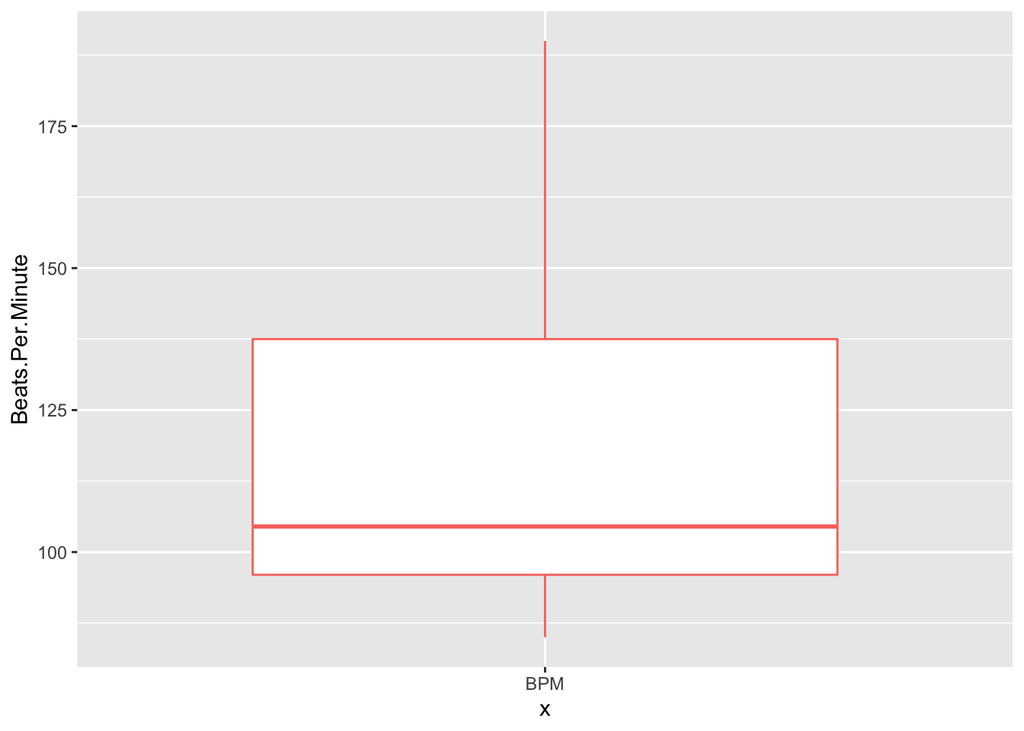

```r
dat%>%
  ggplot()+
  geom_boxplot(aes(x="BPM",y=Beats.Per.Minute,color=BP))+
  theme(legend.position="none")
```

Beats Per Minute is the tempo of a song. Tempo can effect a song’s textural qualities and feel, songs with a higher tempo may feel lighter or more joyful while songs with a lower tempo may feel thicker or more calm. In classical music theory, songs with a tempo around 100-120 BPM are typically seen as lighter happy songs, while songs around 150 BPM can seem stressful. The musical trend for 2019 favored these lighter higher tempo songs like Meduza’s “Piece of Your Heart”.

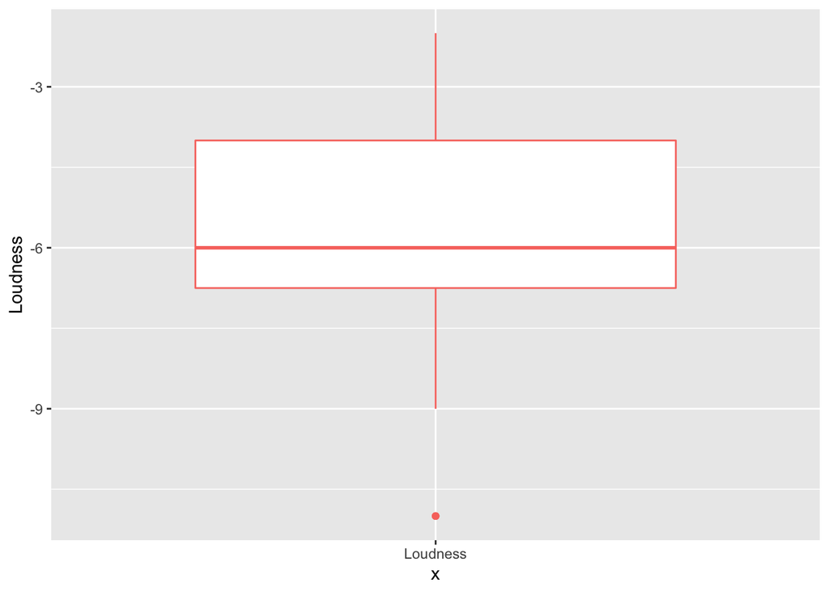

```r
dat%>%
  ggplot()+
  geom_boxplot(aes(x="Loudness",y=Loudness,color=loud))+
  theme(legend.position="none")
```

Loudness describes how loud a song is, the closer to 0 the value is the louder the song is. The top 50 billboard songs for 2019 were attenuated to -6dB, which is a fair bit louder than the -14 dB that Spotify normalizes songs to. This suggests that in 2019 louder songs were favored over quieter songs.

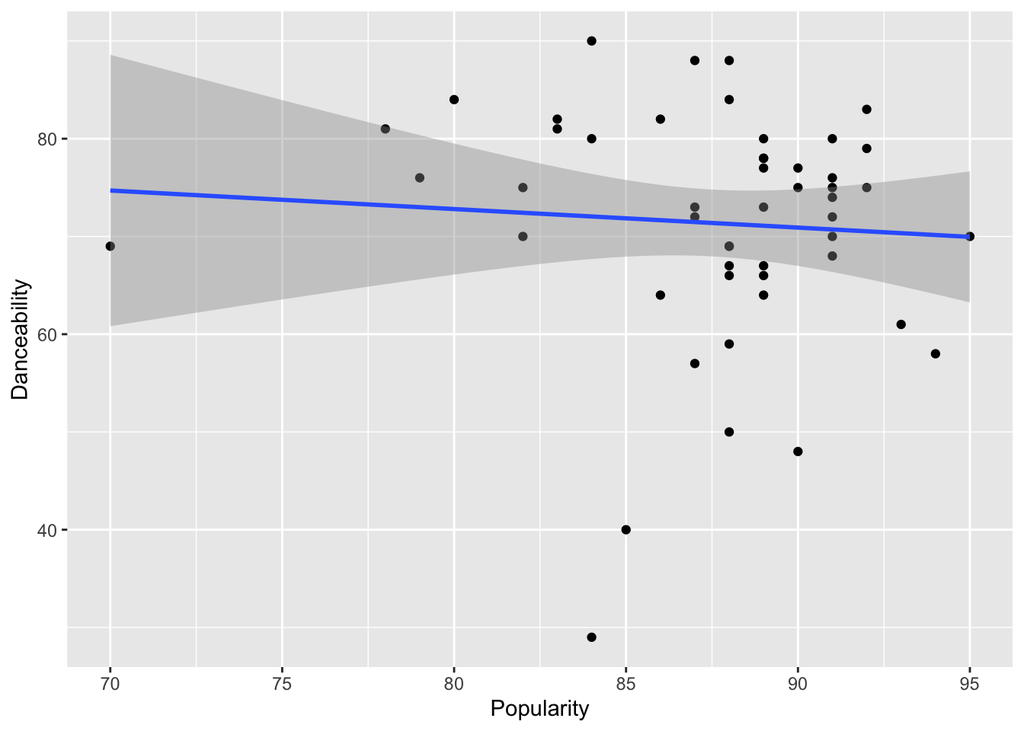

```r
dat%>%
  ggplot()+
  geom_point(aes(x= Popularity, y= Danceability))+
  geom_smooth(aes(x= Popularity, y= Danceability),method = lm,)
```

```r
m1<-lm(dat$Danceability~dat$Popularity)
summary(m1)
```

```
##
## Call:
## lm(formula = dat$Danceability ~ dat$Popularity)
##
## Residuals:
##     Min      1Q  Median      3Q     Max
## -43.044  -4.893   2.241   7.922  17.956
##
## Coefficients:
##                Estimate Std. Error t value Pr(>|t|)
## (Intercept)     87.9771    33.5029   2.626   0.0116 *
## dat$Popularity  -0.1897     0.3824  -0.496   0.6221
## ---
## Signif. codes:  0 '***' 0.001 '**' 0.01 '*' 0.05 '.' 0.1 ' ' 1
##
## Residual standard error: 12.02 on 48 degrees of freedom
## Multiple R-squared:  0.0051, Adjusted R-squared:  -0.01563
## F-statistic: 0.246 on 1 and 48 DF,  p-value: 0.6221
```

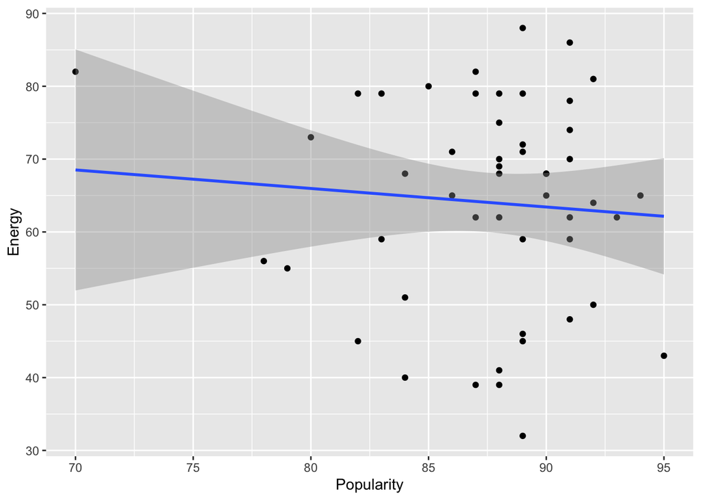

```r
dat%>%
  ggplot()+
  geom_point(aes(x= Popularity, y= Energy))+
  geom_smooth(aes(x= Popularity, y= Energy),method = lm,)
```

```r
m2<-lm(dat$Energy~dat$Popularity)
summary(m2)
```

```
##
## Call:
## lm(formula = dat$Energy ~ dat$Popularity)
##
## Residuals:
##     Min      1Q  Median      3Q     Max
## -31.678 -11.036   2.822  11.008  24.322
##
## Coefficients:
##                Estimate Std. Error t value Pr(>|t|)
## (Intercept)     86.3223    39.9407   2.161   0.0357 *
## dat$Popularity  -0.2544     0.4559  -0.558   0.5794
## ---
## Signif. codes:  0 '***' 0.001 '**' 0.01 '*' 0.05 '.' 0.1 ' ' 1
##
## Residual standard error: 14.33 on 48 degrees of freedom
## Multiple R-squared:  0.006447,   Adjusted R-squared:  -0.01425
## F-statistic: 0.3115 on 1 and 48 DF,  p-value: 0.5794
```

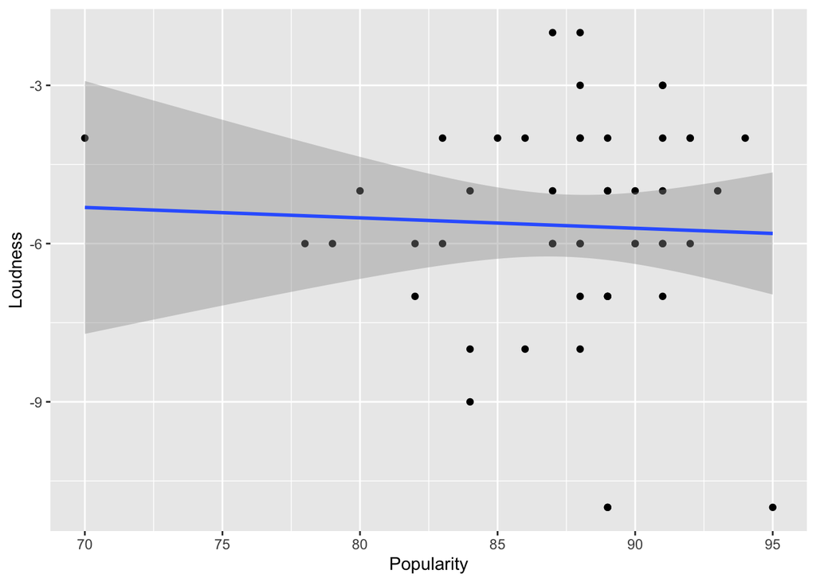

```r
dat%>%
  ggplot()+
  geom_point(aes(x= Popularity, y= Loudness))+
  geom_smooth(aes(x= Popularity, y= Loudness),method = lm,)
```

```r
m3<-lm(dat$Loudness~dat$Popularity)
summary(m3)
```

```
##
## Call:
## lm(formula = dat$Loudness ~ dat$Popularity)
##
## Residuals:
##     Min      1Q  Median      3Q     Max
## -5.3104 -1.0851 -0.2611  1.6255  3.6699
##
## Coefficients:
##                Estimate Std. Error t value Pr(>|t|)
## (Intercept)    -3.93390    5.78457  -0.680    0.500
## dat$Popularity -0.01973    0.06602  -0.299    0.766
##
## Residual standard error: 2.076 on 48 degrees of freedom
## Multiple R-squared:  0.001856,   Adjusted R-squared:  -0.01894
## F-statistic: 0.08927 on 1 and 48 DF,  p-value: 0.7664
```

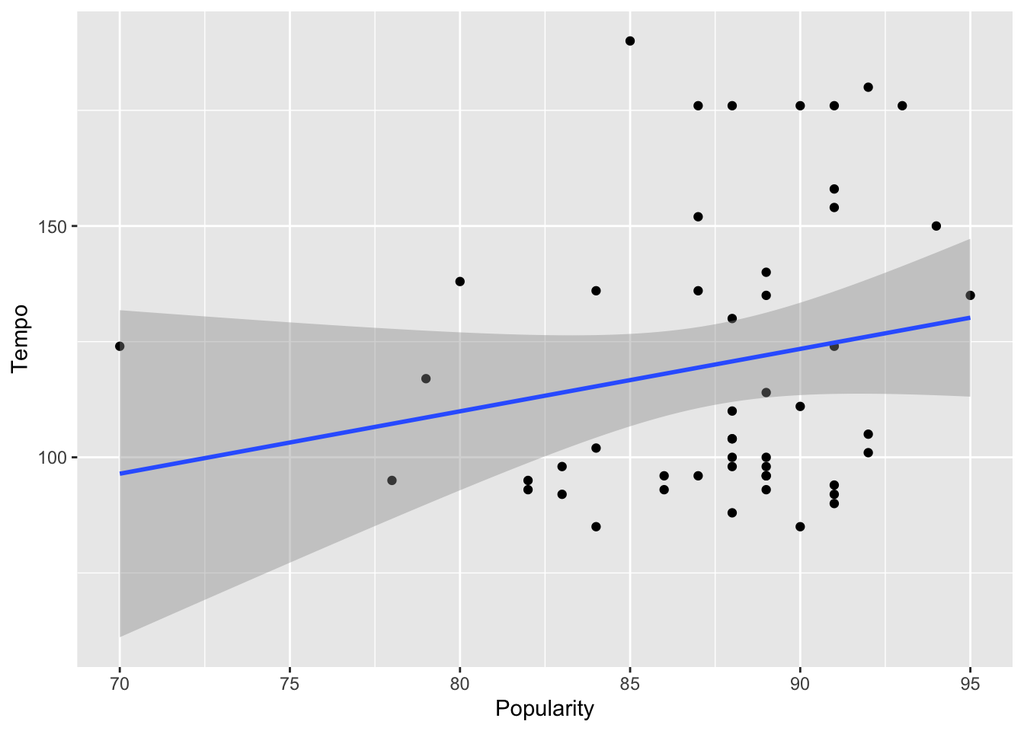

```r
dat%>%
  ggplot()+
  geom_point(aes(x= Popularity, y= Beats.Per.Minute))+
  geom_smooth(aes(x= Popularity, y= Beats.Per.Minute),method = lm,)+
  labs(y="Tempo")
```

```r
m4<-lm(dat$Beats.Per.Minute~dat$Popularity)
summary(m4)
```

```
##
## Call:
## lm(formula = dat$Beats.Per.Minute ~ dat$Popularity)
##
## Residuals:
##    Min     1Q Median     3Q    Max
## -38.43 -23.22 -12.88  21.04  73.31
##
## Coefficients:
##                Estimate Std. Error t value Pr(>|t|)
## (Intercept)      2.0213    85.3057   0.024    0.981
## dat$Popularity   1.3490     0.9737   1.385    0.172
##
## Residual standard error: 30.61 on 48 degrees of freedom
## Multiple R-squared:  0.03845,    Adjusted R-squared:  0.01842
## F-statistic:  1.92 on 1 and 48 DF,  p-value: 0.1723
```